# Exploring the R Bugzilla

Lluís Revilla Sancho

8/28/2021 - 2021-10-25

# Introduction

This is an analysis of the [database dump](https://bugs.r-project.org/db/R-bugs.sql.xz) provided by on `25/03/2021` by Simon Urbanek which is available to all at the previous link (If that fails it is also on [this repository](https://github.com/llrs/bugzilla_viz) as R-bugs.sql .

The goal of this analysis is to identify good practices (or lack of them) to help people submitting better issues and implement helpful advice and rail guard on it to be helpful to the R core members.

# Connecting to the database dump

First an initial exploration of the database and bug reports building on the [previous analysis](https://llrs.github.io/bugzilla_viz/bugRzilla_review.html) we convert some columns to dates:

```r
library("lubridate")
date_columns_bugs <- c("creation_ts", "delta_ts", "lastdiffed", "deadline")
db_bugs <- tbl(db_bugzilla, "bugs") |>
    collect() |>
    mutate(across(!!date_columns_bugs, as.POSIXct, tz = "UTC", format = "%Y-%m-%d %H:%M:%OS"))
```

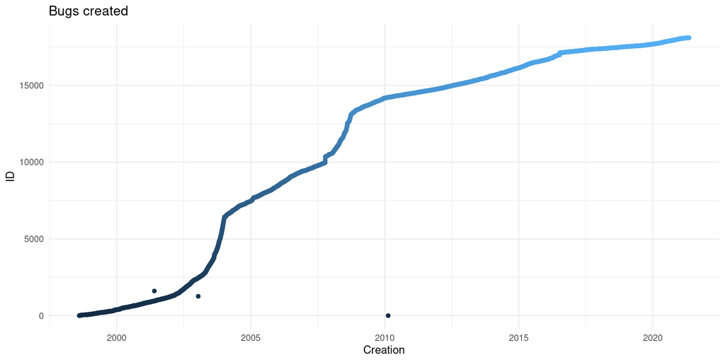

```r
db_bugs |>
    ggplot() +
    geom_point(aes(creation_ts, bug_id, color = bug_id)) +
    labs(title = "Bugs created", y = "ID", x = "Creation") +
    guides(color = "none")
```

There are also three points that do not follow the general expectations[^1].

# Exploring outliers

These three odd bug reports that are not consistent with the path position and numbering of the other bug reports need some exploration.

```r
special_bugs <- c(1, 1261, 1605)
```

Not clear what happens on 1261 or 1605, as there isn’t anything that provides a clue on what could have happened.

However, if we look at the [first bug report](https://bugs.r-project.org/show_bug.cgi?id=1) on the website you’ll realize the first bug is testing Bugzilla! That first bug was made on 2010, in addition some bugs with later id have earlier creation date and even some without any submission date.

Perhaps these bugs were reported by some account with different characteristics. If we check who has been reporting the bugs we see this top users reporting bugs:

```r
db_bugs |>
  count(reporter, sort = TRUE) |>
  head() |>
  knitr::kable(align = "c", col.names = c("User", "Bugs reported"))
```

| User | Bugs reported |
| --- | --- |
| 2 | 3594 |
| 1036 | 73 |
| 963 | 70 |
| 1044 | 62 |
| 1056 | 60 |
| 3256 | 52 |

# Jitterbug and Bugzilla

Looking at the mailing list there are some report of some [troubles migrating](https://stat.ethz.ch/pipermail/r-devel/2010-March/056954.html) the bugs and it is not completely clear from the database when the switch happened. But it is clear that the R project moved from Jitterbug to Bugzilla, so the reporting of bugs changed too. If we explore the bug status and the bug resolution depending on if it was reported by user 2 or not we see the following visualization.

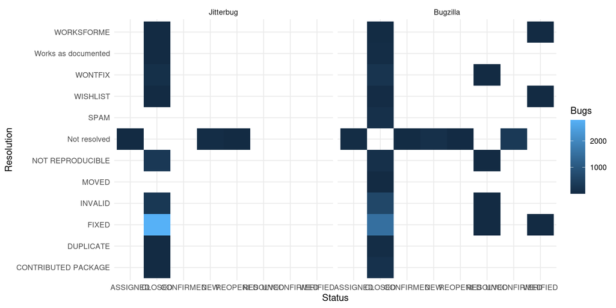

```r
db_bugs2 <- db_bugs |>
  mutate(reported_on = ifelse(reporter == 2, "Jitterbug", "Bugzilla"),
         reported_on = factor(reported_on, levels = c("Jitterbug", "Bugzilla")))
moving_date <- max(db_bugs2$creation_ts[db_bugs2$reported_on == "Jitterbug"],
                   na.rm = TRUE)
db_bugs2 <- db_bugs2 |>
  mutate(modified_on = ifelse(delta_ts >= moving_date, "Bugzilla", "Jitterbug")) |>
  mutate(modified_on = ifelse(is.na(modified_on), "Jitterbug", modified_on)) |>
  mutate(modified_on  = ifelse(reported_on == "Bugzilla", "Bugzilla", modified_on))

db_bugs2 |>
  count(bug_status, resolution, reported_on, sort = TRUE) |>
  mutate(resolution = ifelse(resolution == "", "Not resolved", resolution)) |>
  ggplot() +
  geom_tile(aes(bug_status, resolution, fill = n)) +
  facet_wrap(~reported_on) +
  labs(fill = "Bugs", x = "Status", y = "Resolution")
```

If we focus on the bugs that are not spam and where was the last update we see a complete different picture of status and resolutions:

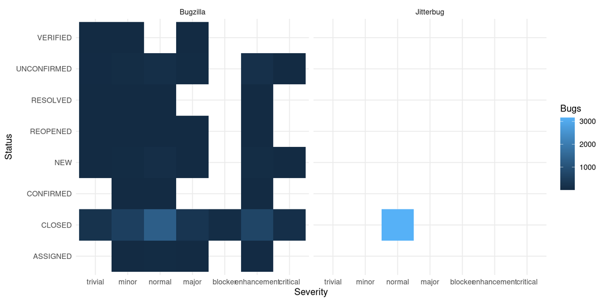

```r
db_bugs3 <- db_bugs2 |>
  filter(resolution != "SPAM") |>
  mutate(bug_severity = fct_relevel(bug_severity,
                                    c("trivial", "minor", "normal", "major", "blocker", "enhancement")))
db_bugs3 |>
  count(bug_severity, bug_status, modified_on, sort = TRUE) |>
  ggplot() +
  geom_tile(aes(bug_severity, bug_status, fill = n)) +
  facet_wrap(~modified_on) +
  labs(x = "Severity", y = "Status", fill = "Bugs")
```

The information about the resolution and status of bugs on Jitterbug is missing from the database. (There is some reports of changes on the comments though)

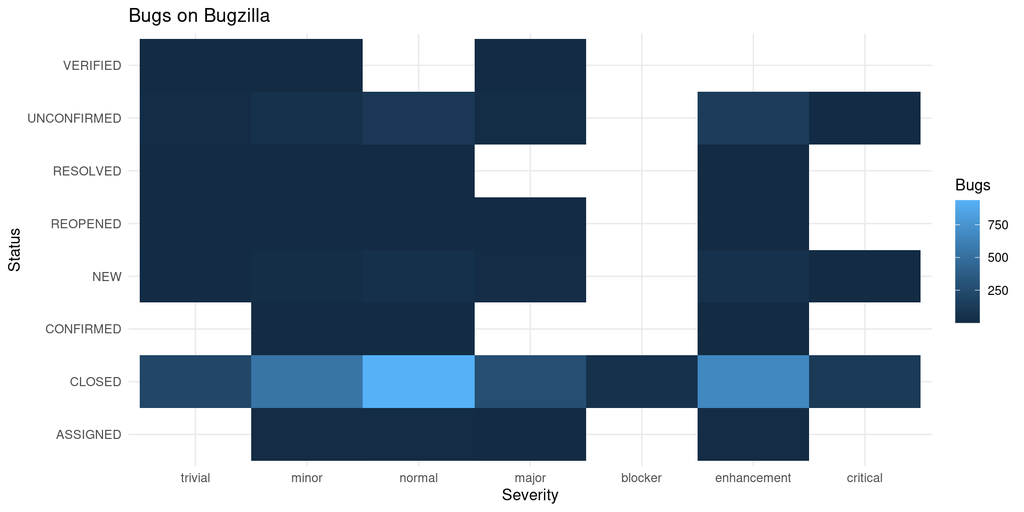

```r
db_bugs4 <- db_bugs3 |>
  filter(reported_on == "Bugzilla",
         bug_id != 1)
db_bugs4 |>
  count(bug_severity, bug_status, sort = TRUE) |>
  ggplot() +
  geom_tile(aes(bug_severity, bug_status, fill = n)) +
  labs(x = "Severity", y = "Status", fill = "Bugs", title = "Bugs on Bugzilla")
```

If we focus only on Bugzilla, most bugs are “normal” but some classification is done on the status and severity. Should someone help classify the bugs to different severity to prioritize working on them?

# First time

Looking at when for the first time some field was used might provide some insight on changes on the way that the bug report system has been modified.

```r
first_time <- function(b, cat) {
  b |>
    filter(bug_id != 1) |>
    group_by({{cat}}) |>
    summarise(bug_id = bug_id[which.min(creation_ts)],
              creation_ts = min(creation_ts, na.rm = TRUE), n = n(), .groups =  "drop") |>
    arrange(creation_ts, bug_id) |>
    mutate(creation_ts = lubridate::date(creation_ts)) |>
    mutate(bug_id = paste0("[", bug_id,
                           "](https://bugs.r-project.org/show_bug.cgi?id=", bug_id, ")"))
}

first_time(db_bugs3, bug_status) |>
  knitr::kable(align = "c", col.names = c("Bug", "Status", "First report", "Total bugs"))
```

| Bug | Status | First report | Total bugs |
| --- | --- | --- | --- |
| CLOSED | 3 | 1998-08-07 | 6334 |
| NEW | 408 | 2000-01-28 | 172 |
| ASSIGNED | 1161 | 2001-11-07 | 43 |
| REOPENED | 8192 | 2005-10-09 | 12 |
| UNCONFIRMED | 14335 | 2010-07-14 | 324 |
| VERIFIED | 14452 | 2010-12-04 | 3 |
| RESOLVED | 16576 | 2015-10-22 | 9 |
| CONFIRMED | 16648 | 2015-12-29 | 13 |

Surprisingly the CONFIRMED and RESOLVED status wasn’t used until 2015. I’ve heard that this was added relatively lately by one R core member.

```r
first_time(db_bugs3, resolution) |>
  knitr::kable(align = "c",
               col.names = c("Resolution", "Bug", "First report", "Total bugs"))
```

| Resolution | Bug | First report | Total bugs |
| --- | --- | --- | --- |
| FIXED | 3 | 1998-08-07 | 4304 |
| WONTFIX | 105 | 1999-01-29 | 336 |
|  | 408 | 2000-01-28 | 564 |
| INVALID | 424 | 2000-02-08 | 935 |
| Works as documented | 837 | 2001-02-01 | 50 |
| NOT REPRODUCIBLE | 848 | 2001-02-13 | 434 |
| WISHLIST | 961 | 2001-05-31 | 36 |
| CONTRIBUTED PACKAGE | 1729 | 2002-07-02 | 157 |
| WORKSFORME | 2888 | 2003-04-30 | 24 |
| DUPLICATE | 8725 | 2006-03-29 | 68 |
| MOVED | 16182 | 2015-02-02 | 2 |

All resolutions were fairly soon used except the moved one.

```r
first_time(db_bugs3, version) |>
  knitr::kable(align = "c", col.names = c("Version", "Bug", "First report", "Total bugs"))
```

| Version | Bug | First report | Total bugs |
| --- | --- | --- | --- |
| old | 3 | 1998-08-07 | 3637 |
| R 3.1.1 | 1662 | 2002-06-13 | 75 |
| R 3.0.2 | 2048 | 2002-09-20 | 152 |
| R 2.14.0 | 6899 | 2004-05-21 | 47 |
| R 3.0.1 | 7991 | 2005-07-06 | 116 |
| R 2.15.1 | 13684 | 2009-05-01 | 58 |
| R 2.y.z | 14229 | 2010-03-13 | 213 |
| R 2.10.x | 14231 | 2010-03-16 | 50 |
| R 2.12.0 | 14272 | 2010-04-27 | 48 |
| R 2.x | 14277 | 2010-04-30 | 13 |
| R 2.11.1 | 14322 | 2010-06-24 | 59 |
| R-devel (trunk) | 14359 | 2010-08-13 | 615 |
| R 2.12.1 | 14464 | 2010-12-20 | 28 |
| R 2.12.2 | 14522 | 2011-03-07 | 19 |
| R 2.13.0 | 14559 | 2011-04-19 | 40 |
| R 2.13.1 | 14605 | 2011-06-14 | 41 |
| R 2.13.2 | 14656 | 2011-08-11 | 17 |
| R 3.0.0 | 14682 | 2011-09-20 | 102 |
| R 2.15.0 | 14832 | 2012-03-04 | 52 |
| R 2.15.x | 14875 | 2012-04-10 | 204 |
| R 2.14.2 | 14879 | 2012-04-13 | 10 |
| R 3.6.xx | 14905 | 2012-05-03 | 87 |
| R 3.1.0 | 15072 | 2012-10-12 | 104 |
| R 3.1.2 | 15522 | 2013-10-31 | 142 |
| R 3.0.3 | 15725 | 2014-03-26 | 10 |
| R 3.4.0 | 16086 | 2014-11-24 | 36 |
| R 3.2.0 | 16321 | 2015-04-17 | 73 |
| R 3.1.3 | 16322 | 2015-04-17 | 19 |
| R 3.2.1 | 16327 | 2015-04-22 | 76 |
| R 3.2.2 | 16558 | 2015-10-08 | 65 |
| R 3.2.3 | 16651 | 2016-01-03 | 69 |
| R 3.2.4 | 16760 | 2016-03-12 | 23 |
| R 3.2.4 revised | 16775 | 2016-03-20 | 15 |
| R 3.3.* | 16776 | 2016-03-21 | 164 |
| R 3.5.2 | 16877 | 2016-05-04 | 10 |
| R 3.4.1 | 17325 | 2017-08-09 | 30 |
| R 3.4.3 | 17384 | 2018-02-01 | 15 |
| R 3.5.0 | 17405 | 2018-04-12 | 145 |
| R 3.4.4 | 17408 | 2018-04-18 | 7 |
| R 3.5.1 | 17468 | 2018-09-12 | 17 |
| R 3.5.3 | 17582 | 2019-07-18 | 2 |
| R 4.0.0 | 17773 | 2020-04-28 | 26 |
| R 4.0.x | 17775 | 2020-04-28 | 179 |

Some bugs reports of previous versions (not sure if version-specific) happen later than on new versions. Probably is people using previous version that report problems they found.

```r
first_time(db_bugs3, bug_severity) |>
  knitr::kable(align = "c", col.names = c("Severity", "Bug", "First report", "Total bugs"))
```

| Severity | Bug | First report | Total bugs |
| --- | --- | --- | --- |
| normal | 3 | 1998-08-07 | 4700 |
| enhancement | 616 | 2000-07-25 | 876 |
| critical | 2048 | 2002-09-20 | 122 |
| major | 9807 | 2007-07-25 | 306 |
| minor | 14229 | 2010-03-13 | 626 |
| trivial | 14252 | 2010-04-10 | 228 |
| blocker | 14265 | 2010-04-22 | 52 |

On 2010 it seems that minor and trivial issues were started to be reported.

```r
component_names <- c("2" = "Accuracy",
                     "3" = "Analyses",
                     "4" = "Graphics",
                     "5" = "Installation",
                     "6" = "Low-level",
                     "8" = "S4methods",
                     "7" = "Misc",
                     "9" = "System-specific",
                     "10" = "Translations",
                     "11" = "Documentation",
                     "12" = "Language",
                     "13" = "Startup",
                     "14" = "Models",
                     "15" = "Add-ons",
                     "16" = "I/O",
                     "17" = "Wishlist",
                     "18" = "Mac GUI / Mac specific",
                     "19" = "Windows GUI / Window specific"
                     )
first_time(db_bugs3, component_id) |>
  mutate(component_id = component_names[as.character(component_id)]) |>
  knitr::kable(align = "c", col.names = c("Component", "Bug", "First report", "Total bugs"))
```

| Component | Bug | First report | Total bugs |
| --- | --- | --- | --- |
| Language | 3 | 1998-08-07 | 411 |
| Models | 4 | 1998-08-10 | 256 |
| System-specific | 7 | 1998-08-17 | 284 |
| I/O | 12 | 1998-08-19 | 301 |
| Documentation | 19 | 1998-08-19 | 712 |
| Startup | 21 | 1998-08-21 | 46 |
| Analyses | 26 | 1998-08-31 | 325 |
| Low-level | 37 | 1998-09-06 | 662 |
| Graphics | 38 | 1998-09-06 | 542 |
| Windows GUI / Window specific | 46 | 1998-09-24 | 438 |
| Installation | 58 | 1998-10-30 | 335 |
| Misc | 91 | 1999-01-09 | 1146 |
| Wishlist | 105 | 1999-01-29 | 462 |
| Add-ons | 122 | 1999-02-18 | 347 |
| Accuracy | 138 | 1999-03-10 | 327 |
| Mac GUI / Mac specific | 1015 | 2001-07-06 | 236 |
| S4methods | 4073 | 2003-09-05 | 55 |
| Translations | 7841 | 2005-05-06 | 25 |

There seems to be interest on translations since 2005, quite early on the development of R.

```r
first_time(db_bugs3, rep_platform) |>
  knitr::kable(align = "c", col.names = c("Platform", "Bug", "First report", "Total bugs"))
```

| Platform | Bug | First report | Total bugs |
| --- | --- | --- | --- |
| All | 3 | 1998-08-07 | 3752 |
| ix86 (32-bit) | 47 | 1998-09-24 | 1297 |
| x86_64/x64/amd64 (64-bit) | 1662 | 2002-06-13 | 1025 |
| Other | 14272 | 2010-04-27 | 813 |
| PowerPC | 14548 | 2011-04-05 | 20 |
| SGI | 14849 | 2012-03-18 | 1 |
| Sparc | 16514 | 2015-08-18 | 2 |

I don’t know what these platforms mean, but there seems that every 3 years there’s a new platform report.

```r
first_time(db_bugs3, op_sys) |>
  knitr::kable(align = "c", col.names = c("OS", "Bug", "First report", "Total bugs"))
```

| OS | Bug | First report | Total bugs |
| --- | --- | --- | --- |
| All | 3 | 1998-08-07 | 2150 |
| Solaris | 4 | 1998-08-10 | 204 |
| Other | 7 | 1998-08-17 | 640 |
| Linux-Fedora | 12 | 1998-08-19 | 124 |
| Linux-Debian | 15 | 1998-08-20 | 114 |
| Linux | 43 | 1998-09-19 | 1287 |
| Windows 32-bit | 47 | 1998-09-24 | 1190 |
| Mac OS X v10.5 | 697 | 2000-10-16 | 85 |
| FreeBSD | 1613 | 2002-05-30 | 22 |
| Linux-Ubuntu | 2048 | 2002-09-20 | 168 |
| Windows 64-bit | 6762 | 2004-04-13 | 512 |
| Mac OS X v10.4 | 7973 | 2005-06-28 | 66 |
| AIX | 13440 | 2009-01-09 | 14 |
| Mac OS X v10.8 | 13684 | 2009-05-01 | 48 |
| Mac OS X v10.6 | 14226 | 2010-03-02 | 87 |
| unix-other | 14463 | 2010-12-18 | 9 |
| Mac OS X v10.7 | 14670 | 2011-09-08 | 25 |
| Linux-RHEL | 15037 | 2012-08-30 | 21 |
| OS X Mavericks | 15520 | 2013-10-30 | 75 |
| OS X Yosemite | 16375 | 2015-05-08 | 27 |
| OS X El Capitan | 16911 | 2016-05-17 | 28 |
| macOS | 17782 | 2020-05-04 | 14 |

Multiple issues on each component, many are reported on Windows and some are reported for all OS.

# Spam

As seen there are some bugs classified as APM. This was a new resolution on Bugzilla. In order to explore this we can check out the missing issues (bug ids that are not present but that later ids are) and spam to see what happened:

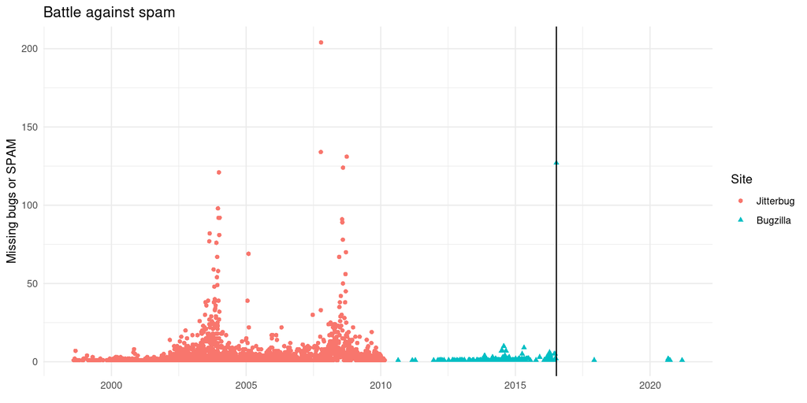

```r
missing_ids <- (db_bugs2$bug_id - lag(db_bugs2$bug_id) -1)
missing_ids[db_bugs2$resolution == "SPAM"] <- 1
missing_ids[is.na(missing_ids)] <- 0
data.frame(bug = db_bugs2$creation_ts,
           spam = missing_ids,
           reported_on = db_bugs2$reported_on) |>
  filter(spam != 0) |>
  ggplot() +
  geom_point(aes(bug, spam, color = reported_on, shape = reported_on)) +
  geom_vline(xintercept = as_datetime("2016-07-10")) +
  labs(title = "Battle against spam",
       y = "Missing bugs or SPAM",
       col = "Site",
       shape = "Site",
       x = element_blank())
```

There are two waves of missing or spam bugs on Jitterbug and later less problems on the move to Bugzilla.

It could also be that there were some problem migrating bugs from Jitterbug and some issues were not correctly moved, or simply that some issues are omitted due to the [security vulnerability policy](https://www.r-project.org/bugs.html) to omit them from appearing on the database. Since the move to Bugzilla there was some constant but low volume spam issue compared to Jitterbug.

But I think that the wave of spam or missing on Bugzilla that is the same day a new SPAM policy was enacted (vertical line) shows that these numbers show mostly spam. After the new policy to ask permission for an account, started where the vertical line is, has worked very well. There seem to be less missing/spam bugs lately. Given all that we will omit the spam bugs from now on. They are not really bug reports nor report or have something of quality to learn from them.

# Attachments

If we look at the attachments we might get some information about the kind of patches, packages, or reproducible examples that are provided.

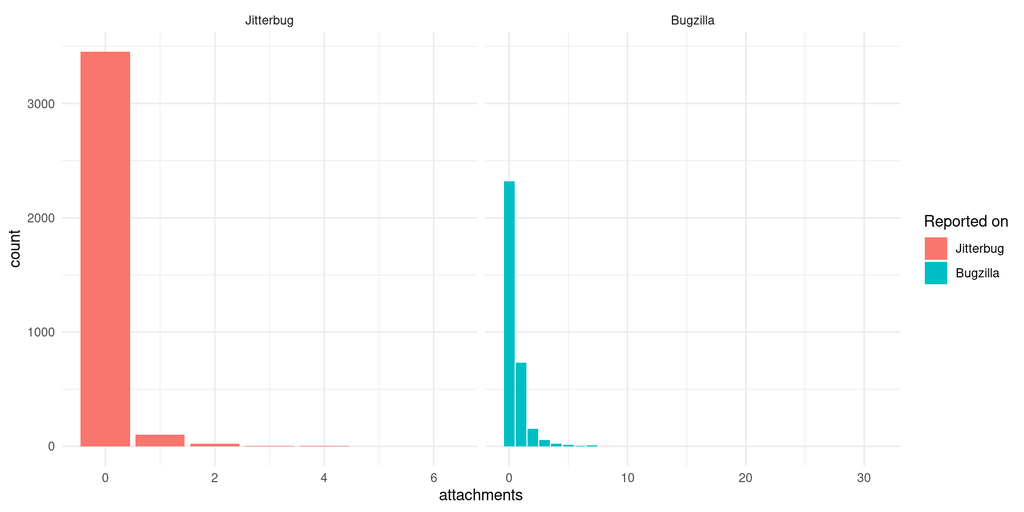

```r
db_attachments <- tbl(db_bugzilla, "attachments") |>
  collect() |>
  mutate(across(c("creation_ts", "modification_time"), as.POSIXct, format = "%Y-%m-%d %H:%M:%OS", tz = "UTC"))
db_attachments_bugs <- db_bugs3 |>
    left_join(db_attachments, by = "bug_id", suffix = c(".bug", ".at"))
db_attachments_bugs |>
  group_by(bug_id, reported_on) |>
  summarize(attachments = sum(!is.na(creation_ts.at))) |>
  ungroup() |>
  ggplot() +
  geom_bar(aes(attachments, fill = reported_on)) +
  facet_wrap(~reported_on, scales = "free_x") +
  labs(fill = "Reported on")
## `summarise()` has grouped output by 'bug_id'. You can override using the `.groups` argument.
```

Most bug reports don’t have attachments! So this means that they are just some reporting of a problem which the R core then needs to understand and figure a solution. Surprisingly some bug reports have many attachments, this might be related to a refinement on patches or exploring several options.

```r
db_attachments_bugs |>
  group_by(bug_id) |>
  summarize(have_attachments = any(!is.na(creation_ts.at)),
            x = creation_ts.bug,
            y = bug_id,
            reported_on = reported_on) |>
  ungroup() |>
  count(reported_on, have_attachments, sort = TRUE) |>
  knitr::kable(align = "c",
               col.names = c("Reported on", "Attachments", "Bugs"))
## `summarise()` has grouped output by 'bug_id'. You can override using the `.groups` argument.
```

| Reported on | Attachments | Bugs |
| --- | --- | --- |
| Jitterbug | FALSE | 3453 |
| Bugzilla | FALSE | 2321 |
| Bugzilla | TRUE | 1592 |
| Jitterbug | TRUE | 201 |

Proportionally there are more attachments on Bugzilla.

Perhaps some attachments weren’t moved from Jitterbug, but it seems that the large difference might be from an increase in participation and patches proposed on Bugzilla.

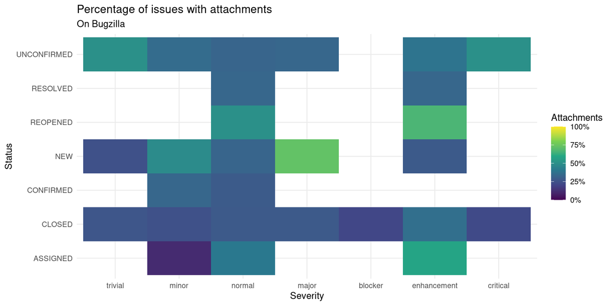

```r
attachments_type <- db_attachments_bugs |>
  group_by(bug_severity, bug_status, bug_id, reported_on) |>
  summarize(have_attachments = any(!is.na(creation_ts.at)),
            n_attachments = sum(!is.na(creation_ts.at))/n()) |>
  ungroup() |>
  group_by(bug_severity, bug_status, reported_on) |>
  count(n_attachments) |>
  mutate(attached = n_attachments > 0) |>
  group_by(bug_severity, bug_status, reported_on) |>
  mutate(p = n/sum(n)) |>
  filter(attached)
## `summarise()` has grouped output by 'bug_severity', 'bug_status', 'bug_id'. You can override using the `.groups` argument.

attachments_type |>
  filter(reported_on == "Bugzilla") |>
  ggplot() +
  geom_tile(aes(bug_severity, bug_status, fill = p)) +
  scale_fill_viridis_c(labels = scales::percent_format(), limits = c(0, 1)) +
  labs(title = "Percentage of issues with attachments",
       subtitle = "On Bugzilla", fill = "Attachments",
       x = "Severity", y = "Status")
```

Looking at which severity has more attachments and which status, is kind of confusing. Probably the attachment is more related to who is reporting the bug or people proposing solutions.

What is the time between posting the bug and the attachments?

```r
attachment_time <- db_attachments_bugs |>
    filter(!is.na(creation_ts.at),
           !is.na(creation_ts.bug)) |>
    filter(reported_on == "Bugzilla") |>
    mutate(t = creation_ts.at - creation_ts.bug,
           mt0 = t == 0)
attachment_in <- attachment_time |>
  filter(!mt0) |>
  group_by(bug_id) |>
  arrange(t) |>
  slice_head(n = 1) |>
  ungroup() |>
  summarize(attachment_in = as.numeric(median(t), units = "hours")) |>
  pull(attachment_in)
attachment_time |>
  count(mt0) |>
  mutate(p = round(n/sum(n)*100, 2)) |>
  knitr::kable(col.names = c("Attachment on  opening", "Bugs", "%"), align = "c")
```

| Attachment on opening | Bugs | % |
| --- | --- | --- |
| FALSE | 881 | 55.34 |
| TRUE | 711 | 44.66 |

Bugs with attachments on opening are almost 50% and when not on opening there is an attachment in around 19.63 hours.

Exploring some issues like 7022 it seems that changes on tagging and notes is posted as comments. If we want to look at comments and time between changes this will distort the results, even more, we want to improve bug reports for Bugzilla not jitterbug. So from now we will only work with Bugzilla bugs.

```r
db_attachments_bugs |>
  filter(reported_on == "Bugzilla",
         !is.na(mimetype)) |>
  group_by(ispatch) |>
  count(mimetype, sort = TRUE) |>
  head() |>
  knitr::kable(row.names = FALSE, align = "c",
               col.names = c("Is patch?", "mimetype", "Bugs"), digits = 0)
```

| Is patch? | mimetype | Bugs |
| --- | --- | --- |
| 1 | text/plain | 773 |
| 0 | text/plain | 287 |
| 0 | application/octet-stream | 128 |
| 0 | image/png | 89 |
| 0 | application/pdf | 42 |
| 0 | application/x-gzip | 42 |

Most files attached are not patches, even not all plain text files attached are patches. They might be packages showing the issues, plots where the deffect is apparent or files with data for examples.

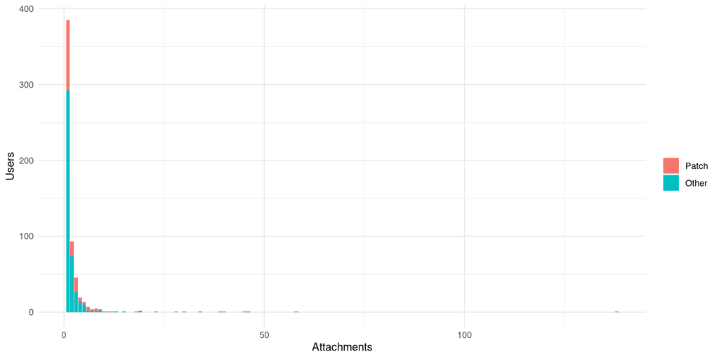

```r
db_attachments_bugs |>
  filter(reported_on == "Bugzilla",
         !is.na(mimetype)) |>
  group_by(ispatch) |>
  count(submitter_id, sort = TRUE) |>
  ggplot() +
  geom_bar(aes(n, fill = factor(ispatch, labels = c("Patch", "Other"),
                                levels = c(1, 0)))) +
  labs(fill = "", y = "Users", x = "Attachments")
```

Most people submit just one file and few submit more than file. Of those there are very few patches (as detected by the system) This might suggest that people either don’t find bugs easy to patch, (or know how to do that) or they provide patches through other ways (r-devel mailing list for instance).

# Activity on bugs reports

The bugs reports receive some attention and change if people performs some action through the Bugzilla tracker. If we look at the changes and addition to bugs we might get some idea of what is needed or missing from bug reports:

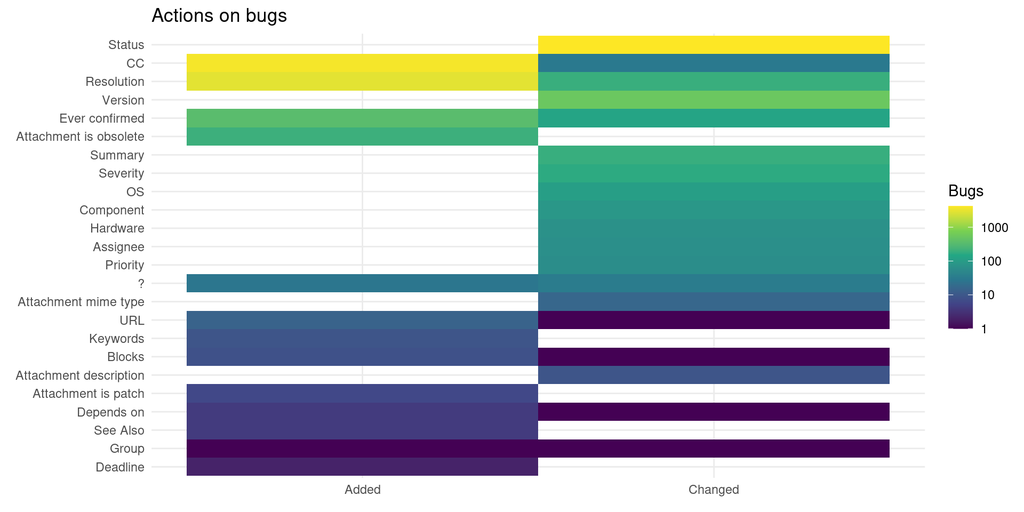

```r
db_activity <- tbl(db_bugzilla, "bugs_activity") |>
  collect() |>
  mutate(bug_when = as.POSIXct(bug_when, tz = "UTC", format = "%Y-%m-%d %H:%M:%OS")) |>
  filter(bug_id %in% db_bugs4$bug_id)


field_names <- c(
  "2" = "Summary",
  "5" = "Version",
  "6" = "Hardware",
  "7" = "URL",
  "8" = "OS",
  "9" = "Status",
  "11" = "Keywords",
  "12" = "Resolution",
  "13" = "Severity",
  "14" = "Priority",
  "15" = "Component",
  "16" = "Assignee",
  "20" = "CC",
  "21" = "Depends on",
  "22" = "Blocks",
  "23" = "Attachment description",
  "25" = "Attachment mime type",
  "26" = "Attachment is patch",
  "27" = "Attachment is obsolete",
  "34" = "?",
  "36" = "Ever confirmed",
  "39" = "Group",
  "40" = "?",
  "41" = "?",
  "42" = "Deadline",
  "47" = "?",
  "54" = "See Also"
)

db_activity2 <- db_activity |>
  mutate(field = field_names[as.character(fieldid)])

db_activity2 |>
  count(field, adding = ifelse(removed %in% c("", "0"), "Added", "Changed")) |>
  tidyr::pivot_longer(cols = adding,
                      names_to = "type", values_to = "value") |>
  ggplot() +
  geom_tile(aes(value, fct_reorder(field, n, .fun = sum), fill = n)) +
  scale_fill_viridis_c(trans = "log10") +
  labs(x = element_blank(), y = element_blank(), title = "Actions on bugs",
       fill = "Bugs")
```

Changes on bug are on status, or people subscribing (usually via commenting on the issue). The ones that users can work to improve and provide better version description and title (Summary), followed by the severity, assigning to the right group, choosing the right OS, component and hardware.

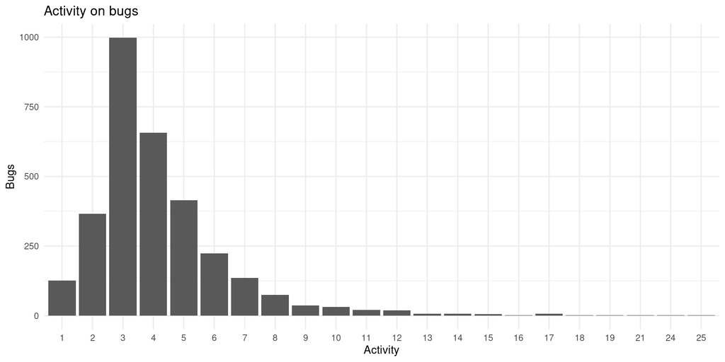

```r
db_activity2 |>
  count(bug_id, sort = TRUE) |>
  count(n) |>
  mutate(n = as.factor(n)) |>
  ggplot() +
  geom_col(aes(x = n, y = nn)) +
  labs(x = "Activity", y = "Bugs", title = "Activity on bugs")
## Storing counts in `nn`, as `n` already present in input
## ℹ Use `name = "new_name"` to pick a new name.
```

```r
db_activity2 |>
    select(bug_id, field) |>
    arrange(bug_id, field) |>
    group_by(bug_id) |>
    summarize(fields = list(unique(field))) |>
    ungroup() |>
    count(fields, sort = TRUE) |>
    mutate(size = lengths(fields)) |>
    filter(n > 100) |>
    pull(fields) |>
    vapply( paste, collapse = ", ", FUN.VALUE = character(1L))
```

```
## [1] "CC, Resolution, Status"
## [2] "Resolution, Status"
## [3] "CC, Resolution, Status, Version"
## [4] "CC, Ever confirmed, Resolution, Status"
## [5] "CC"
## [6] "Resolution, Status, Version"
```

The components also change quite frequently:

```r
db_activity2 |>
  filter(field == "Component") |>
  group_by(added) |>
  count(sort = TRUE) |>
  head() |>
  knitr::kable(col.names = c("Component", "Bugs"))
```

| Component | Bugs |
| --- | --- |
| Wishlist | 15 |
| Accuracy | 8 |
| Low-level | 8 |
| Misc | 8 |
| Mac GUI / Mac specific | 6 |
| Windows GUI / Window specific | 6 |

Generally it seems that components are changed to make them wishlist.

```r
db_activity2 |>
  filter(field == "OS") |>
  group_by(added) |>
  count(sort = TRUE) |>
  head() |>
  knitr::kable(col.names = c("OS", "Bugs"))
```

| OS | Bugs |
| --- | --- |
| All | 60 |
| Windows 64-bit | 15 |
| Linux | 5 |
| Mac OS X v10.9 | 4 |
| Windows 32-bit | 4 |
| Linux-Ubuntu | 3 |

And OS changes are to make it either more specific or more frequently more general.

```r
db_activity2 |>
  filter(field == "Hardware") |>
  group_by(added) |>
  count(sort = TRUE) |>
  head() |>
  knitr::kable(col.names = c("Hardware", "Bugs"))
```

| Hardware | Bugs |
| --- | --- |
| All | 48 |
| x86_64/x64/amd64 (64-bit) | 18 |
| ix86 (32-bit) | 1 |
| PowerPC | 1 |

Hardware changes seems to be the report more general.

However, as seen the numbers of these changes are quite low. The highest are the status, resolution and adding someone to the list of CC. This usually happens when someone comments. So how many comments are on issues?

# Comments on bug reports

Looking at the comments on bug reports we we’ll see how much exchange is there usually:

```r
db_comments <- db_bugzilla |>
  tbl("longdescs") |>
  collect() |>
  mutate(bug_when = as.POSIXct(bug_when, tz = "UTC",
                               format = "%Y-%m-%d %H:%M:%OS")) |>
  filter(bug_id %in% db_bugs4$bug_id)
```

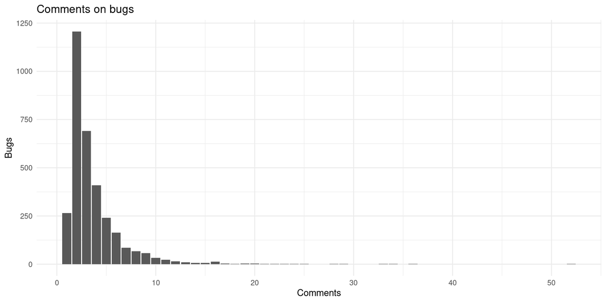

```r
## Warning in .local(conn, statement, ...): Decimal MySQL column 4 imported as
## numeric

db_comments |>
  count(bug_id) |>
  count(n) |>
  mutate(n = n) |>
  ggplot() +
  geom_col(aes(n, nn)) +
  # scale_y_continuous(trans = "log10") +
  labs(x = "Comments", y = "Bugs", title = "Comments on bugs")
## Storing counts in `nn`, as `n` already present in input
## ℹ Use `name = "new_name"` to pick a new name.
```

This means that usually there are around 3 comments on each issue. Some issues create long threads of over 50 comments!

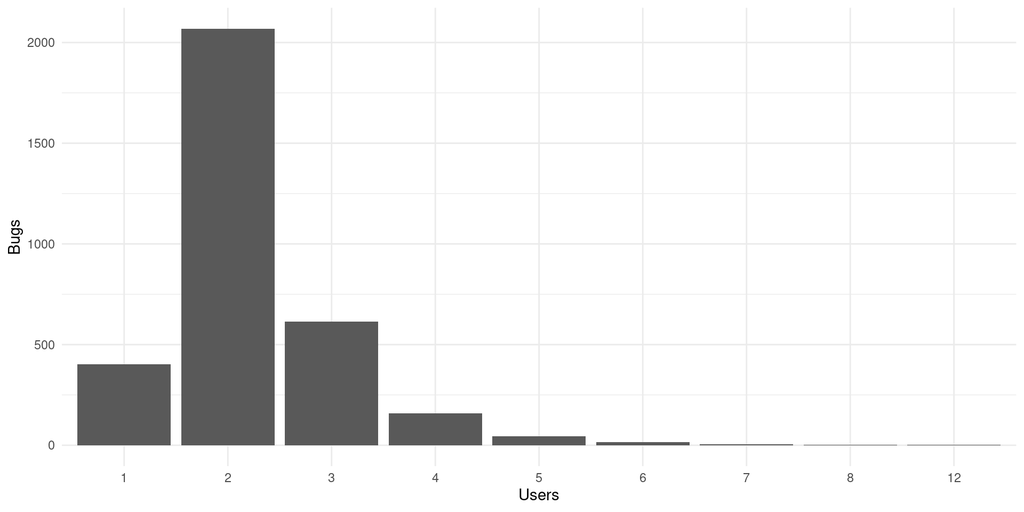

```r
db_comments |>
  group_by(bug_id) |>
  summarise(n_commenters = n_distinct(who)) |>
  count(n_commenters) |>
  mutate(n_commenters = as.factor(n_commenters)) |>
  ggplot() +
  geom_col(aes(n_commenters, n)) +
  # scale_y_continuous(trans = "log10") +
  labs(x = "Users", y = "Bugs")
```

Most comments on bugs are from 2 different people. Presumably one is the author and another user (here the initial opening comment is not accounted for).

```r
r_core <- c(3, 5, 9, 18, 19, 28, 34, 54, 137, 151, 216, 308, 413, 420, 1249,
            1330, 2442)
w <- count(db_comments, who, sort = TRUE)
w2 <- w$n
names(w2) <- as.character(w$who)
f <- fgsea::fgsea(pathways = list("R core"= as.character(r_core)), stats = w2,
                  scoreType = "pos")
```

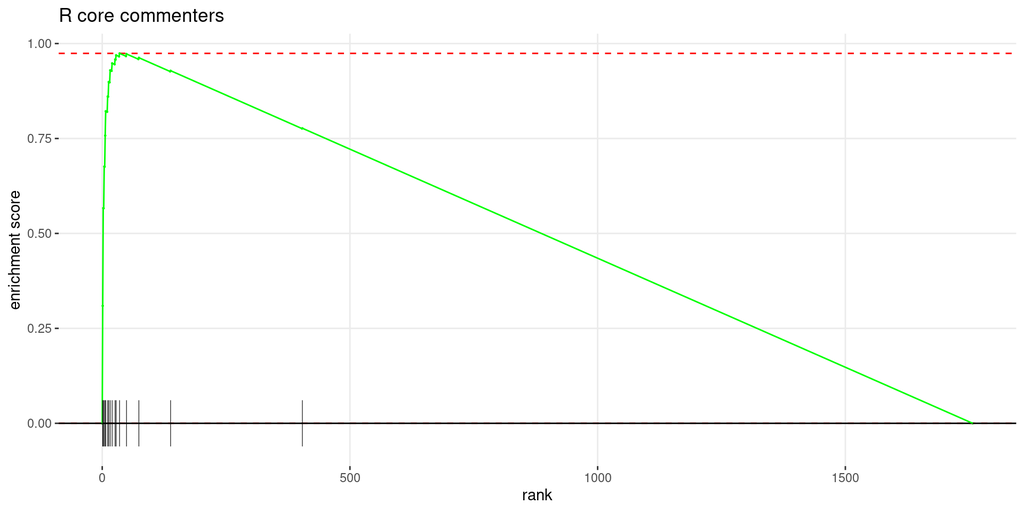

```r
fgsea::plotEnrichment(r_core, stats = w2) + labs(title = "R core commenters")
```

The users that comment most are from the R core. We can see when did they comment for the first time and how much do have they commented.

```r
db_comments |>
  filter(who %in% r_core) |>
  group_by(who) |>
  summarize(first_date = lubridate::date(min(bug_when)),
            last_date = lubridate::date(max(bug_when)),
            n = n_distinct(bug_id), .groups = "drop") |>
  arrange(-n) |>
  select(-who) |>
  knitr::kable(col.names = c("First comment", "Last comment", "Bugs id commented"))
```

| First comment | Last comment | Bugs id commented |
| --- | --- | --- |
| 2010-03-18 | 2020-08-16 | 789 |
| 2010-03-18 | 2021-05-08 | 644 |
| 2010-03-24 | 2021-04-14 | 335 |
| 2015-04-23 | 2021-04-29 | 228 |
| 2010-04-07 | 2021-03-31 | 172 |
| 2013-10-16 | 2021-03-08 | 123 |
| 2010-03-26 | 2021-04-28 | 121 |
| 2011-08-18 | 2018-01-14 | 65 |
| 2013-07-04 | 2021-05-04 | 57 |
| 2013-09-12 | 2020-12-09 | 41 |
| 2010-07-03 | 2021-02-10 | 31 |
| 2011-06-01 | 2018-03-20 | 23 |
| 2010-05-07 | 2016-06-01 | 17 |
| 2010-07-15 | 2021-04-25 | 11 |
| 2010-03-19 | 2012-09-26 | 8 |
| 2010-09-16 | 2011-02-14 | 2 |

Looking at when they first commented on a bug, and last and how many bugs they did reply, we can see that there are some members that are very involved on replying issues. [^2].

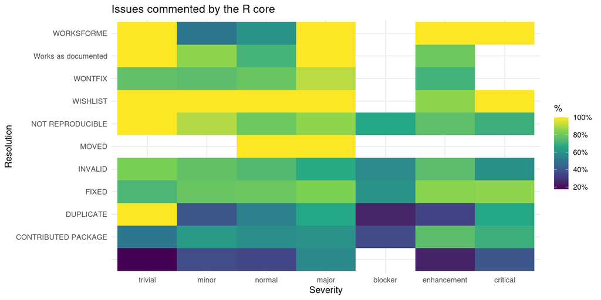

```r
db_comments |>
  merge(db_bugs4, by = "bug_id") |>
  group_by(bug_id) |>
  summarize(author = ifelse(any(who %in% r_core), "R core", "Others"),
            bug_severity = unique(bug_severity[!is.na(bug_severity)]),
            resolution = unique(resolution[!is.na(resolution)])) |>
  ungroup() |>
  count(author, bug_severity, resolution, sort = TRUE)  |>
  group_by(bug_severity, resolution) |>
  mutate(p = n/sum(n)) |>
  filter(author != "Others") |>
  ggplot() +
  geom_tile(aes(bug_severity, resolution, fill = p)) +
  scale_fill_viridis_c(labels = scales::percent_format()) +
  labs(title = "Issues commented by the R core",
       x = "Severity", y = "Resolution", fill = "%")
```

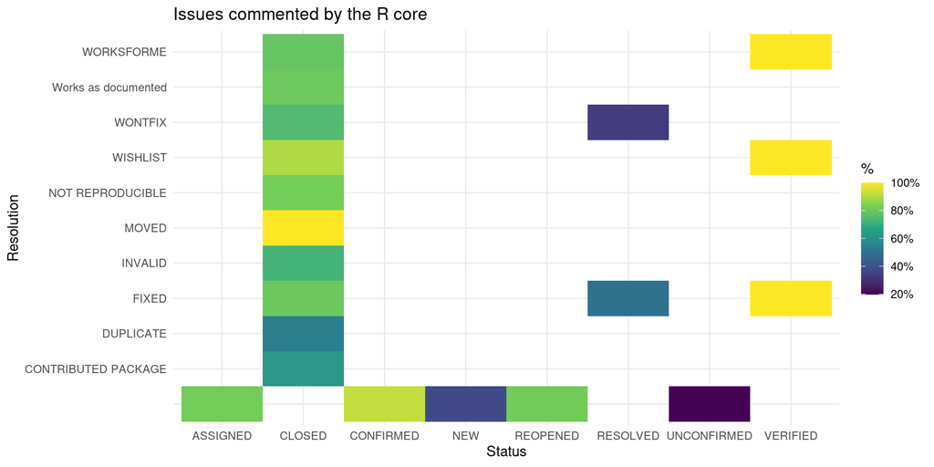

```r
db_comments |>
  merge(db_bugs4, by = "bug_id") |>
  group_by(bug_id) |>
  summarize(author = ifelse(any(who %in% r_core), "R core", "Others"),
            bug_status = unique(bug_status[!is.na(bug_status)]),
            resolution = unique(resolution[!is.na(resolution)])) |>
  ungroup() |>
  count(author, bug_status, resolution, sort = TRUE)  |>
  group_by(bug_status, resolution) |>
  mutate(p = n/sum(n)) |>
  filter(author != "Others") |>
  ggplot() +
  geom_tile(aes(bug_status, resolution, fill = p)) +
  scale_fill_viridis_c(labels = scales::percent_format()) +
  labs(title = "Issues commented by the R core",
       x = "Status", y = "Resolution", fill = "%")
```

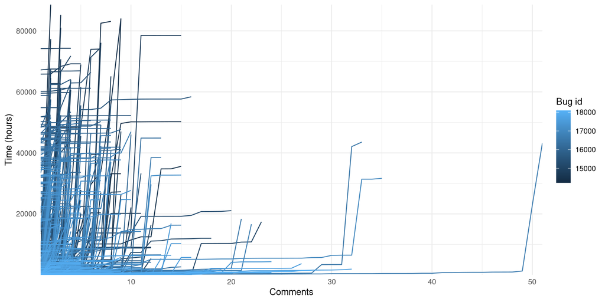

```r
comments_time <- db_comments |>
  merge(db_bugs4, by = "bug_id", all = TRUE) |>
  mutate(diff_t = difftime(bug_when, creation_ts, units = "hours")) |>
  group_by(bug_id) |>
  arrange(diff_t) |>
  mutate(n = seq_len(n())) |>
  ungroup() |>
  filter(n != 1) |>
  mutate(n = n-1)

ggplot(comments_time) +
  geom_line(aes(n, diff_t, col = bug_id, group = bug_id)) +
  scale_y_continuous(expand = expansion()) +
  scale_x_continuous(expand = expansion()) +
  labs(col = "Bug id", x = "Comments", y = "Time (hours)")
```

Looking at the when comments happens it seems that there are two groups of issues. One group where it takes long time to receive the first comment. And another group where lots of comments pour in the first hours and much later a some more comments.

```r
comments_time |>
  group_by(n_comments = n) |>
  summarize(median = median(diff_t, na.rm = TRUE),
            sd = sd(diff_t, na.rm = TRUE),
            n = n()) |>
  ungroup() |>
  head() |>
  knitr::kable(align = "c",
               col.names = c("Comment number", "Time (hours)", "Sd time (hours)", "Bugs"))
```

| Comment number | Time (hours) | Sd time (hours) | Bugs |
| --- | --- | --- | --- |
| 1 | 10.75250 hours | 8757.988 | 3051 |
| 2 | 47.15389 hours | 11469.239 | 1845 |
| 3 | 118.74361 hours | 13403.934 | 1154 |
| 4 | 165.50153 hours | 13772.120 | 744 |
| 5 | 213.30639 hours | 13092.839 | 504 |
| 6 | 270.41750 hours | 13310.764 | 341 |

The first comment of an issue is usually quite fast but there are many bugs that their first comment is around a year later.

If we exclude replies from the same user that reported the issue the time are higher:

```r
comments_time |>
  filter(reporter != who) |>
  group_by(n_comments = n) |>
  summarize(median = median(diff_t, na.rm = TRUE),
            sd = sd(diff_t, na.rm = TRUE),
            n = n()) |>
  ungroup() |>
  head() |>
  knitr::kable(align = "c",
               col.names = c("Comment number", "Time (hours)", "Sd time (hours)", "Bugs"))
```

| Comment number | Time (hours) | Sd time (hours) | Bugs |
| --- | --- | --- | --- |
| 1 | 16.67486 hours | 9622.714 | 2410 |
| 2 | 98.05708 hours | 14143.851 | 1056 |
| 3 | 153.28236 hours | 15275.750 | 768 |
| 4 | 313.90417 hours | 15931.168 | 457 |
| 5 | 356.92000 hours | 15170.771 | 350 |
| 6 | 418.95222 hours | 15207.167 | 221 |

This both suggests that reporters might provide more information soon after creating the issue and that the time till some other people provides some feedback is higher.

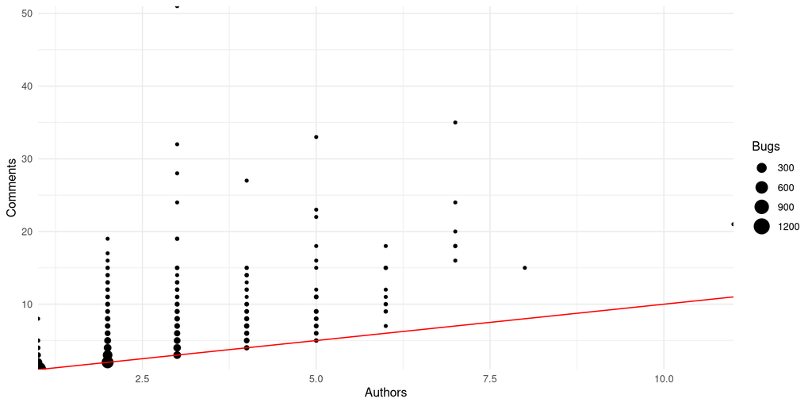

```r
comments_time |>
  group_by(bug_id) |>
  summarize(n_who = n_distinct(who), n_comments = n()) |>
  ungroup() |>
  ggplot() +
  geom_count(aes(n_who, n_comments)) +
  scale_y_continuous(expand = expansion()) +
  scale_x_continuous(expand = expansion()) +
  # scale_size(trans = "log10", range = c(0, 5)) +
  labs(size = "Bugs", x = "Authors", y = "Comments") +
  geom_abline(slope = 1, intercept = 0, col = "red")
```

# R contributors

So the question is who is contributing so much. Who are the most contributing users and how are they contributing? I’ll focus on bugs opened the last 3 years (before the database dump).

```r
begin <- max(db_bugs4$creation_ts, na.rm = TRUE) - lubridate::years(3)

opener <- db_bugs4 |>
    select(bug_id, time = creation_ts, user = reporter) |>
    mutate(action = "open") |>
    filter(time >= begin)

commenter <- db_comments |>
    filter(bug_id %in% opener$bug_id) |>
    select(bug_id, time = bug_when, user = who) |>
    mutate(action = "comment")

attacher <- db_attachments_bugs |>
    filter(bug_id %in% opener$bug_id) |>
    filter(!is.na(creation_ts.at),
           bug_id %in% db_bugs4$bug_id) |>
    select(bug_id, time = creation_ts.at, user = submitter_id) |>
    mutate(action = "attach")

db_activity_bugs <- db_activity2 |>
  merge(db_bugs4, by = "bug_id", all.y = TRUE)

status <- db_activity_bugs |>
    filter(bug_id %in% opener$bug_id) |>
    select(bug_id,  time = bug_when, user = who, field, added) |>
    filter(field == "Status") |>
    select(-field, action = added) |>
    filter(action != "NEW")

# Select last 3 years of data
history <- rbind(opener, commenter, attacher, status) |>
    arrange(bug_id, time) |>
    filter(time >= begin)

# Keep only bugs opened on the last 3 years (not comments before them and so on)
# history <- history[min(which(history$action == "open")):nrow(history), ]
# Commented to keep all actions even on older bugs

# all actions including on their own reports
actions_users <- history |>
    filter(action %in% c("open", "comment", "attach")) |>
    group_by(user) |>
    count(action, sort = TRUE) |>
    tidyr::pivot_wider(names_from = action, values_from = n,
                       values_fill = 0) |>
    arrange(user) |>
    mutate(all_comment = ifelse(is.na(comment), 0, comment),
           all_attach = ifelse(is.na(attach), 0, attach),
           r_core = ifelse(user %in% r_core, "yes", "no"),
           user = as.character(user)) |>
    ungroup() |>
    select(-comment, -attach, -open)

# Actions on other issues (except opening)
act_o <- history |>
    group_by(user) |>
    summarize(comment = sum(action == "comment" & !bug_id %in% bug_id[action == "open"], na.rm = TRUE),
              attach = sum(action == "attach" & !bug_id %in% bug_id[action == "open"], na.rm = TRUE),
              open = sum(action == "open", na.rm = TRUE)) |>
    ungroup() |>
    mutate(r_core = ifelse(user %in% r_core, "yes", "no"),
           user = as.character(user))
```

We can look at the list of people that open more bugs, comment on other issues and attach files on other issues:

```r
m <- merge(actions_users, act_o) |>
    mutate(self_comments = all_comment - comment,
           self_attach = all_attach - attach)
active_users <- m |> filter(r_core == "no") |>
    rowwise() |>
    mutate(actions = sum(comment, attach, open)) |>
    ungroup() |>
    arrange(-actions)
ids <- as.numeric(active_users$user[1:30])

library("bugRzilla") # Still experimental
bugRzilla:::use_key()
## ✓ Using key `R_BUGZILLA`.
gu <- get_user(ids = as.numeric(ids), host = "https://rbugs-devel.urbanek.info/")
active_users_merged <- merge(gu[, 1:2], active_users,
                             by.x = "id", by.y = "user",
                             all.x = TRUE, all.y = FALSE) |>
    select(-r_core, -self_comments, -self_attach) |>
    arrange(-actions) |>
    mutate(real_name = ifelse(real_name == "", NA_character_, real_name))
active_users_merged |>
    mutate(real_name = if_else(is.na(real_name), "", real_name)) |>
    knitr::kable(
        col.names = c("ID", "Name", "All comments", "All attachments",
                      "Comments", "Attachments", "Bugs", "Actions"))
```

| ID | Name | All comments | All attachments | Comments | Attachments | Bugs | Actions |
| --- | --- | --- | --- | --- | --- | --- | --- |
| 3299 |  | 100 | 2 | 99 | 1 | 1 | 101 |
| 963 | Suharto Anggono | 115 | 39 | 55 | 7 | 21 | 83 |
| 274 | Sebastian Meyer | 80 | 24 | 49 | 11 | 18 | 78 |
| 430 | Benjamin Tyner | 59 | 4 | 52 | 4 | 5 | 61 |
| 3256 | Michael Chirico | 110 | 51 | 2 | 1 | 52 | 55 |
| 1044 | Kevin Ushey | 65 | 10 | 4 | 0 | 35 | 39 |
| 1036 | Henrik Bengtsson | 56 | 14 | 9 | 1 | 26 | 36 |
| 2307 | Lionel Henry | 41 | 25 | 6 | 2 | 20 | 28 |
| 1056 | Bill Dunlap | 28 | 0 | 1 | 0 | 21 | 22 |
| 2801 | Bob Rudis | 19 | 4 | 16 | 2 | 2 | 20 |
| 1299 | Gabriel Becker | 52 | 28 | 0 | 0 | 18 | 18 |
| 11 | Ben Bolker | 14 | 0 | 11 | 0 | 3 | 14 |
| 114 | Gabor Csardi | 26 | 8 | 4 | 0 | 10 | 14 |
| 610 | Jeroen Ooms | 15 | 4 | 6 | 1 | 7 | 14 |
| 1602 |  | 53 | 16 | 0 | 0 | 13 | 13 |
| 6 | Duncan Murdoch | 22 | 7 | 0 | 0 | 12 | 12 |
| 921 | Dirk Eddelbuettel | 17 | 4 | 4 | 0 | 7 | 11 |
| 1715 | Herv� Pag�s | 24 | 1 | 5 | 1 | 5 | 11 |
| 2885 | Jan Gorecki | 14 | 1 | 1 | 0 | 9 | 10 |
| 3051 | Xianying Tan | 20 | 0 | 4 | 0 | 6 | 10 |
| 3228 | Emil Bode | 16 | 4 | 0 | 0 | 10 | 10 |
| 3344 | Joe Cheng | 7 | 3 | 7 | 3 | 0 | 10 |
| 2264 | Neal Fultz | 20 | 5 | 0 | 0 | 9 | 9 |
| 317 | Mikko Korpela | 9 | 0 | 5 | 0 | 3 | 8 |
| 847 | Pavel N. Krivitsky | 15 | 2 | 0 | 0 | 8 | 8 |
| 1251 | Arni Magnusson | 13 | 8 | 0 | 0 | 8 | 8 |
| 1849 | Andre Mikulec | 21 | 4 | 1 | 0 | 7 | 8 |
| 3330 | André Gillibert | 20 | 10 | 0 | 0 | 8 | 8 |
| 3376 | Hangfan Zhang | 14 | 3 | 0 | 0 | 8 | 8 |
| 2040 | Bill Denney | 16 | 1 | 0 | 0 | 7 | 7 |

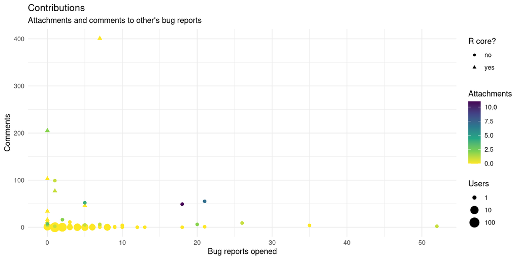

```r
library("ggrepel")
p <- ggplot(act_o) +
    geom_count(aes(open, comment, col = attach, shape = r_core)) +
    scale_size(range = c(2, 6), trans = "log10") +
    labs(x = "Bug reports opened", y = "Comments", shape = "R core?",
         size = "Users", title = "Contributions", subtitle = "Attachments and comments to other's bug reports", col = "Attachments") +
    scale_color_viridis_c(direction = -1)
p
```

We can see that the R core members contribute a lot with many comments as previously explored. There is also a group of people consistently opening many bugs, and some users not in the R core contributing with many attachments.

If we check with the list above we can see these contributors activity:

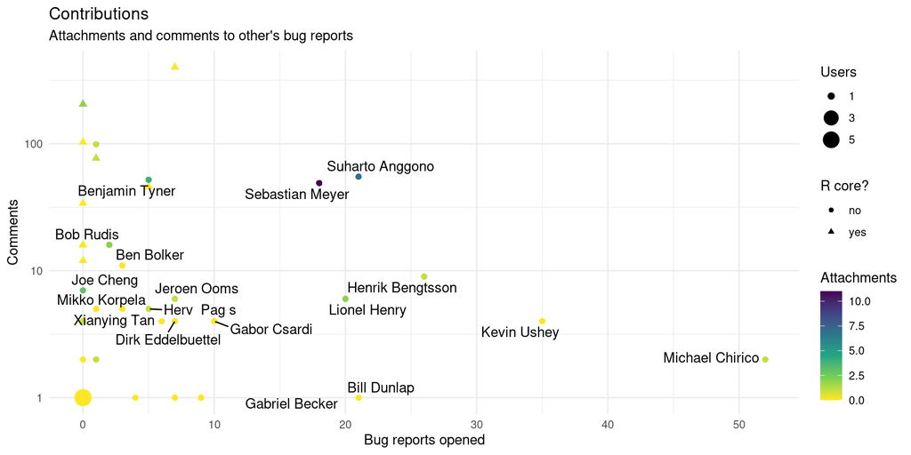

```r
p +
    geom_text_repel(aes(open, comment, label = real_name),
                    data = active_users_merged) +
    scale_y_log10()
```

Note that this plot is on log10 scale on the y axis.